# Obtaining songs from 16th March 2023 to 21st October 2021

This study finds the most popular songs in the important metropolitan cities of the US such as LA, Chicago, Miami, NY, SF, and Dallas from Oct 2021 to Mar 2023, and presents them in the form of a video. This analysis will help us analyze the music preferences of important cities and the longetivity of songs in a particular city.

```python
# package imports
import requests
import json
from datetime import datetime, timedelta
import time
import pickle
```

```python
base_url = "https://charts-spotify-com-service.spotify.com/auth/v0/charts/citytoptrack-{city}-weekly/{date}"
cities = ['losangeles', 'chicago', 'miami', 'newyorkcity', 'sanfrancisco', 'dallas']
```

```python
def obtain_most_popular_songs():
    most_popular_song = {}
    for city in cities:
        most_popular_song[city] = []

    current_date = datetime.strptime('2023-03-16', '%Y-%m-%d').date() # using today's date

    while (current_date.__str__() != '2021-10-14'):
        for city in cities:
            print(f"Most popular song for city: {city} for date: {current_date}")

            payload={}
            url = base_url.format(city=city, date=current_date)

            headers = {
              'authority': 'charts-spotify-com-service.spotify.com',
              'accept': 'application/json',
              'accept-language': 'en-US,en;q=0.9',
              'app-platform': 'Browser',
              'authorization': 'Bearer BQCFGn8iGCTKo-2QXL3Rx30nKdvL7HsrbuGJnx2gZLtmHyfYUgiBEyEeIzO-lRJgYRjuVhCfEp-PZtGgXrwNgkQIuP75fnwINXbuw69YyTfZIfliC-mOXT9GEAMkL69S82PY9STY-XSkJPYUnOJAO8-OX8DiAz6-Nlxp2rBzH9vRdZIuL95zckyUIePiNPYcvRKve9qLVVgWS2_FCI_ut7IyQQ',
              'content-type': 'application/json',
              'origin': 'https://charts.spotify.com',
              'referer': 'https://charts.spotify.com/',
              'sec-ch-ua': '"Google Chrome";v="111", "Not(A:Brand";v="8", "Chromium";v="111"',
              'sec-ch-ua-mobile': '?0',
              'sec-ch-ua-platform': '"Windows"',
              'sec-fetch-dest': 'empty',
              'sec-fetch-mode': 'cors',
              'sec-fetch-site': 'same-site',
              'spotify-app-version': '0.0.0.production',
              'user-agent': 'Mozilla/5.0 (Windows NT 10.0; Win64; x64) AppleWebKit/537.36 (KHTML, like Gecko) Chrome/111.0.0.0 Safari/537.36'
            }

            time.sleep(1)

            response = requests.request("GET", url, headers=headers, data=payload)
            print(response)
            response = response.json()

            most_popular_song_for_city_for_week_name = response['entries'][0]["trackMetadata"]["trackName"]
            most_popular_song_for_city_for_week_image =  response['entries'][0]["trackMetadata"]["displayImageUri"]

            most_popular_song_for_city_for_week = (most_popular_song_for_city_for_week_name, most_popular_song_for_city_for_week_image)

            most_popular_song[city].append(most_popular_song_for_city_for_week)

        current_date = current_date - timedelta(days=7)

    return most_popular_song
```

```python
# most_popular_songs = obtain_most_popular_songs()
```

```python
# with open('most_popular_songs.pickle', 'wb') as f:
#     pickle.dump(most_popular_songs, f)
```

```python
most_popular_songs = None
with open('most_popular_songs.pickle', 'rb') as f:
    most_popular_songs = pickle.load(f)
```

```python
# Obtain coordinates for cities
city_names = ['Los Angeles', 'Chicago', 'Miami', 'New York City', 'San Francisco', 'Dallas']
city_coordinates = []

for city_name in city_names:

    time.sleep(0.5)

    # Send a GET request to the OpenStreetMap geocoding API
    response = requests.get(f'https://nominatim.openstreetmap.org/search?q={city_name}&format=json')

    # Parse the JSON response and extract the coordinates of the first result
    if response.status_code == 200:
        data = response.json()
        if len(data) > 0:
            lat = float(data[0]['lat'])
            lon = float(data[0]['lon'])
            city_coordinates.append([lat, lon])
        else:
            print(f'No results found for {city_name}.')
    else:
        print(f'Error {response.status_code}: {response.reason}.')
```

```python
# Make a map and plot on it
# This takes a lot of time: ~1-2 hours
"""
import folium
import io
from PIL import Image
import os

try:
    os.mkdir("./images")
except FileExistsError:
    pass

file_idx = 0

for week_idx in reversed(range(len(most_popular_songs['miami']))):

    file_idx += 1
    print(f"Creating {file_idx} for week_idx {week_idx}")

    us_map = folium.Map(location=[37.0902, -95.7129], zoom_start=4)

    for i in range(len(city_names)):
        city_coord = city_coordinates[i]

        # Add text and image as label for the marker
        folium.Marker(location=city_coord, icon=folium.features.CustomIcon(most_popular_songs[cities[i]][week_idx][1], icon_size=(50, 50)), popup=most_popular_songs[cities[i]][week_idx][0]).add_to(us_map)

        if city_names[i] == 'San Francisco':
            html = f
#                 <div style="margin-top: 80px;">
#                     <div style="font-weight: bold; font-size: 19px; display: inline-block;">{city_names[i]}</div>
#                     <div style="font-style: italic; font-weight: bold; font-size: 16px; display: inline-block;">{most_popular_songs[cities[i]][week_idx][0]}</div>
#                 </div>

        else:
            html = f
#                 <div style="margin-left: 45px; margin-bottom: 20px;">
#                     <div style="font-weight: bold; font-size: 20px; display: inline-block;">{city_names[i]}</div>
#                     <div style="font-style: italic; font-weight: bold; font-size: 16px; display: inline-block;">{most_popular_songs[cities[i]][week_idx][0]}</div>
#                 </div>


        # Visible text for song
        folium.Marker(location=city_coord, icon=folium.features.DivIcon(html=html)).add_to(us_map)

    # Add this to images
    time.sleep(1)
    img_data = us_map._to_png(10)
    img = Image.open(io.BytesIO(img_data))
    img.save(f'./images/image_{file_idx}.png')

    break
"""
```

[output not shown]

```python
from moviepy.editor import ImageSequenceClip
import os

from moviepy.editor import *

# Get all the images from the directory
path = './images/'
images = [os.path.join(path, img) for img in os.listdir(path) if img.endswith('.png')]
images = sorted(images, key=lambda x: int(x.split('_')[1].split('.')[0]))
print(images)

clips = [ImageClip(m).set_duration(0.25) for m in images]

concat_clip = concatenate_videoclips(clips, method="compose")
concat_clip.write_videofile("analysis.mp4", fps=12)
```

```
['./images/image_1.png', './images/image_2.png', './images/image_3.png', './images/image_4.png', './images/image_5.png', './images/image_6.png', './images/image_7.png', './images/image_8.png', './images/image_9.png', './images/image_10.png', './images/image_11.png', './images/image_12.png', './image…
Moviepy - Building video analysis.mp4.
Moviepy - Writing video analysis.mp4
```

```
Moviepy - Done !
Moviepy - video ready analysis.mp4
```

```python
from IPython.display import HTML

# Display the video using the HTML5 video tag
HTML('<video controls src="analysis.mp4" width="640" height="480">')
```

[video not shown]

```python
# longest streak for a particular song
import pandas as pd


df = pd.DataFrame(most_popular_songs)
```

```python
df.head()
```

|  | losangeles | chicago | miami | newyorkcity | sanfrancisco | dallas |
| --- | --- | --- | --- | --- | --- | --- |
| 0 | (Boy's a liar Pt. 2, https://i.scdn.co/image/a... | (Last Night, https://i.scdn.co/image/ab67616d0... | (TQG, https://i.scdn.co/image/ab67616d00001e02... | (Boy's a liar Pt. 2, https://i.scdn.co/image/a... | (Kill Bill, https://i.scdn.co/image/ab67616d00... | (Last Night, https://i.scdn.co/image/ab67616d0... |
| 1 | (Boy's a liar Pt. 2, https://i.scdn.co/image/a... | (Last Night, https://i.scdn.co/image/ab67616d0... | (TQG, https://i.scdn.co/image/ab67616d00001e02... | (Boy's a liar Pt. 2, https://i.scdn.co/image/a... | (Kill Bill, https://i.scdn.co/image/ab67616d00... | (Last Night, https://i.scdn.co/image/ab67616d0... |
| 2 | (Boy's a liar Pt. 2, https://i.scdn.co/image/a... | (Boy's a liar Pt. 2, https://i.scdn.co/image/a... | (TQG, https://i.scdn.co/image/ab67616d00001e02... | (Boy's a liar Pt. 2, https://i.scdn.co/image/a... | (Kill Bill, https://i.scdn.co/image/ab67616d00... | (Kill Bill, https://i.scdn.co/image/ab67616d00... |
| 3 | (Boy's a liar Pt. 2, https://i.scdn.co/image/a... | (Kill Bill, https://i.scdn.co/image/ab67616d00... | (Boy's a liar Pt. 2, https://i.scdn.co/image/a... | (Boy's a liar Pt. 2, https://i.scdn.co/image/a... | (Kill Bill, https://i.scdn.co/image/ab67616d00... | (Kill Bill, https://i.scdn.co/image/ab67616d00... |
| 4 | (Kill Bill, https://i.scdn.co/image/ab67616d00... | (Kill Bill, https://i.scdn.co/image/ab67616d00... | (Flowers, https://i.scdn.co/image/ab67616d0000... | (Kill Bill, https://i.scdn.co/image/ab67616d00... | (Kill Bill, https://i.scdn.co/image/ab67616d00... | (Kill Bill, https://i.scdn.co/image/ab67616d00... |

```python
# Find maximum consecutive occurrences
max_consec = {}
for col in df.columns:
    max_count = 0
    cur_count = 1
    cur_elem = df[col][0]
    max_elem = cur_elem
    for i in range(1, len(df[col])):
        if df[col][i] == cur_elem:
            cur_count += 1
            if cur_count > max_count:
                max_count = cur_count
                max_elem = cur_elem
        else:
            cur_count = 1
            cur_elem = df[col][i]

    if cur_count > max_count:
        max_count = cur_count
        max_elem = cur_ele

    max_consec[col] = (max_elem, max_count)

print(json.dumps(max_consec, indent=4))
```

```
{
    "losangeles": [
        [
            "Me Porto Bonito",
            "https://i.scdn.co/image/ab67616d00001e0249d694203245f241a1bcaa72"
        ],
        14
    ],
    "chicago": [
        [
            "Kill Bill",
            "https://i.scdn.co/image/ab67616d00001e020c471c36970b9406233842a5"
        ],
        5
    ],
    "miami": [
        [
            "Me Porto Bonito",
            "https://i.scdn.co/image/ab67616d00001e0249d694203245f241a1bcaa72"
        ],
        18
    ],
    "newyorkcity": [
        [
            "Me Porto Bonito",
            "https://i.scdn.co/image/ab67616d00001e0249d694203245f241a1bcaa72"
        ],
        7
    ],
    "sanfrancisco": [
        [
            "Bad Habit",
            "https://i.scdn.co/image/ab67616d00001e0268968350c2550e36d96344ee"
        ],
        11
    ],
    "dallas": [
        [
            "Super Gremlin",
            "https://i.scdn.co/image/ab67616d00001e02565821887210741234f504e4"
        ],
        7
    ]
}
```

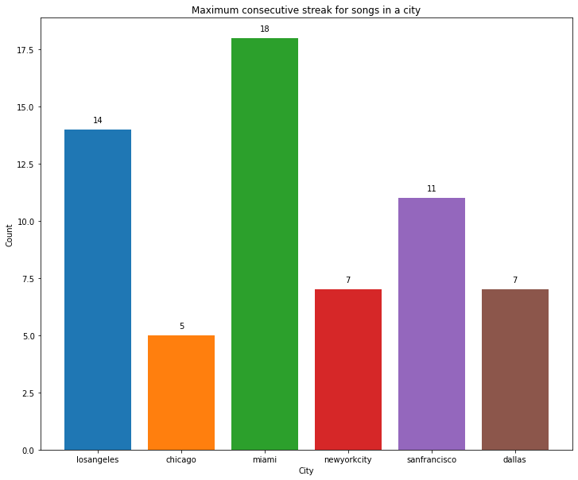

```python
import matplotlib.pyplot as plt

# create a figure and axis object
fig, ax = plt.subplots(figsize=(12, 10))

# loop through the city data dictionary and plot the bars with images
for i, (city, (image_info, count)) in enumerate(max_consec.items()):
    # add the bar to the plot
    ax.bar(city, count)
    # add the count above the bar
    ax.text(city, count+0.25, str(count), ha='center', va='bottom')

# set the axis labels and title
ax.set_xlabel('City')
ax.set_ylabel('Count')
ax.set_title('Maximum consecutive streak for songs in a city')

# show the plot
plt.show()
fig.savefig('maximum_streak.png')
```

From the above graph, we can see that cities such as Los Angeles, Miami, and San Francisco have a higher streak than Chicago, New York City, and Dallas. While Los Angeles and Miami can be considered as music hubs and therefore they are expected to have a high consecutive streak, cities such as Chicago and New York have a surprisingly low streak despite them being music and cultural hubs as well.

On the other hand, San Francisco being a cultural centre and being close to Los Angeles can lead to having a high count.

Dallas isn't a cultural centre nor close to a major music hub, so it can be expected to have low count.

```python
# Find maximum occurrence in the time period

max_songs = {}
for city in cities:
    max_songs[city] = [list(df.groupby(city).size().idxmax()), df.groupby(city).size().max()]
```

```python
max_songs
```

```
{'losangeles': [['Me Porto Bonito',
   'https://i.scdn.co/image/ab67616d00001e0249d694203245f241a1bcaa72'],
  14],
 'chicago': [['Kill Bill',
   'https://i.scdn.co/image/ab67616d00001e020c471c36970b9406233842a5'],
  8],
 'miami': [['Me Porto Bonito',
   'https://i.scdn.co/image/ab67616d00001e0249d694203245f241a1bcaa72'],
  21],
 'newyorkcity': [['Me Porto Bonito',
   'https://i.scdn.co/image/ab67616d00001e0249d694203245f241a1bcaa72'],
  11],
 'sanfrancisco': [['Bad Habit',
   'https://i.scdn.co/image/ab67616d00001e0268968350c2550e36d96344ee'],
  12],
 'dallas': [['Me Porto Bonito',
   'https://i.scdn.co/image/ab67616d00001e0249d694203245f241a1bcaa72'],
  10]}
```

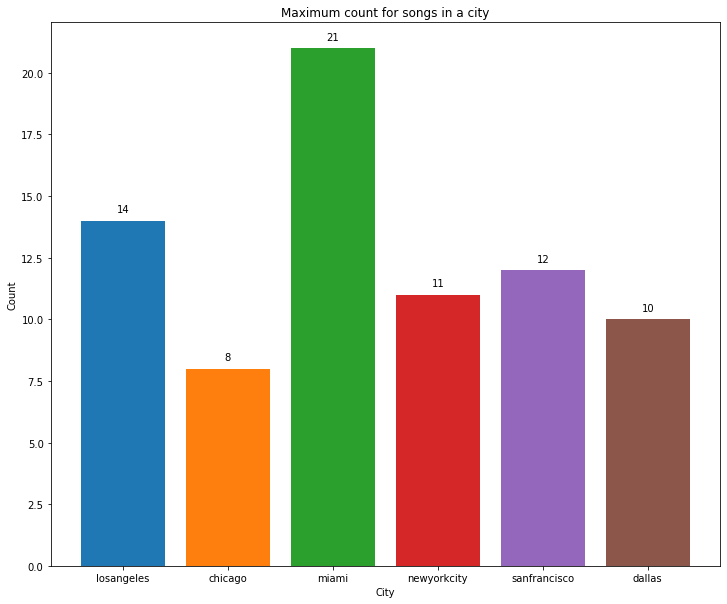

```python
import matplotlib.pyplot as plt
from io import BytesIO

# create a figure and axis object
fig, ax = plt.subplots(figsize=(12, 10))

# loop through the city data dictionary and plot the bars with images
for i, (city, (image_info, count)) in enumerate(max_songs.items()):
    ax.bar(city, count)
    # add the count above the bar
    ax.text(city, count+0.25, str(count), ha='center', va='bottom')

# set the axis labels and title
ax.set_xlabel('City')
ax.set_ylabel('Count')
ax.set_title('Maximum count for songs in a city')

# show the plot
plt.show()

fig.savefig('maximum_occurrence.png')
```

Similar to the previous graph, we see that Los Angeles and Miami have high count while New York and Chicago have surprisingly low counts. We can also draw similar conclusions for San Francisco and Dallas.

```python
final_df = pd.DataFrame(columns=['city', 'max_consec_song', 'max_consec_count', 'max_occur_song', 'max_occur_count'])
for city in cities:
    new_df_dict = {}
    new_df_dict['city'] = city
    new_df_dict['max_consec_song'] = max_consec[city][0][0]
    new_df_dict['max_consec_count'] = max_consec[city][1]
    new_df_dict['max_occur_song'] = max_songs[city][0][0]
    new_df_dict['max_occur_count'] = max_songs[city][1]

    final_df = final_df.append(new_df_dict, ignore_index=True)

#     new_df = pd.DataFrame([city, max_consec[city][0][0], max_consec[city][1], max_songs[city][0][0], max_songs[city][1]], columns=df.columns)
```

```python
final_df
```

|  | city | max_consec_song | max_consec_count | max_occur_song | max_occur_count |
| --- | --- | --- | --- | --- | --- |
| 0 | losangeles | Me Porto Bonito | 14 | Me Porto Bonito | 14 |
| 1 | chicago | Kill Bill | 5 | Kill Bill | 8 |
| 2 | miami | Me Porto Bonito | 18 | Me Porto Bonito | 21 |
| 3 | newyorkcity | Me Porto Bonito | 7 | Me Porto Bonito | 11 |
| 4 | sanfrancisco | Bad Habit | 11 | Bad Habit | 12 |
| 5 | dallas | Super Gremlin | 7 | Me Porto Bonito | 10 |

From the above data, we can conclude that except for Dallas, which is neither a cultural centre nor close to a music hub, the rest of the cities have the same most popular song that had the maximum consecutive streak as the most popular song that had the maximum number of total occurrences. This shows that in such cultural centres and music hubs, if there is a consecutive song streak for the most popular song, then there’s a high chance that it might have the maximum total occurrence throughout the period.